# Alpha-hemolysin

## Figure 7: All clusters contact-map mosaic (small multiples).

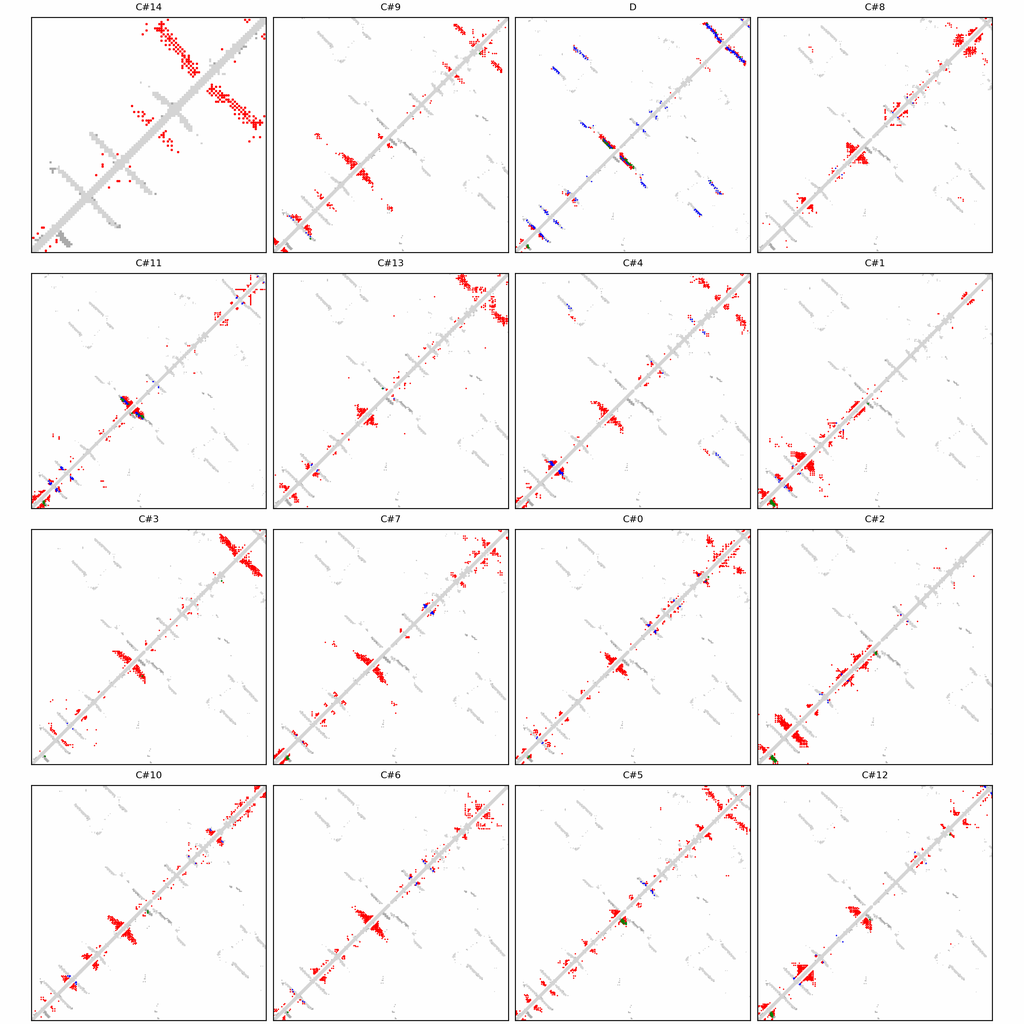

## Figure 8: Phylo null: tree with shuffled cluster fold labels.

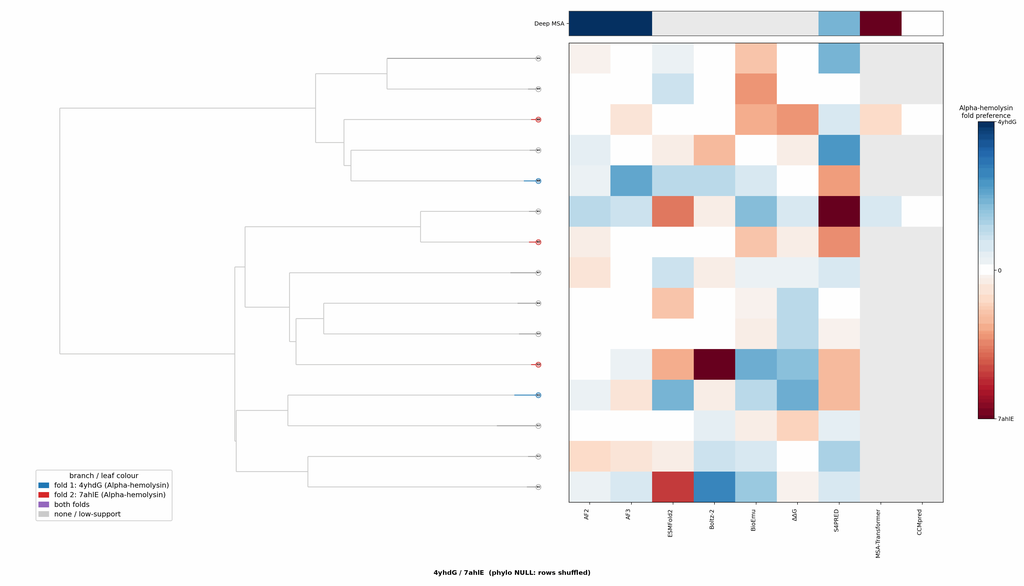

## Cluster metrics table

Per-cluster metrics underlying the figures above.

| cluster | n | neff | AF2_TM1 | AF2_TM2 | AF3_TM1 | AF3_TM2 | RE-MSAT-COM | RE-MSAT1 | RE-MSAT2 | ESM_SEQIDS | ESM_TM1 | ESM_TM2 | ΔΔG_Bias | ΔΔG_Bias_std | ΔΔG_frac_F1 | Boltz2_pref | S4PRED_pref | CCMpred_pref | BioEmu_pref |
| --- | --- | --- | --- | --- | --- | --- | --- | --- | --- | --- | --- | --- | --- | --- | --- | --- | --- | --- | --- |
| Deep | - | - | 0.96 | 0.78 | 0.98 | 0.79 | 0.29 | 0.29 | 0.32 | - | - | - | - | - | - | - | 0.0 | 0.0 | - |
| 000 | 58.0 | 5.0 | 0.24 | 0.21 | 0.29 | 0.28 | 0.0 | 0.0 | 0.01 | 002; 002; 001; 001; 010; 004; 004; 009; 003; 003 | 0.81 ± 0.03 | 0.68 ± 0.02 | -13.94 | 3.58 | 0.0 | 0.04 | 0.0 | 0.0 | 0.02 |
| 001 | 44.0 | 6.0 | 0.78 | 0.7 | 0.86 | 0.78 | 0.0 | 0.01 | 0.0 | 003; 003; 005; 008; 008; 005; 009; 009; 001; 001 | 0.80 ± 0.03 | 0.68 ± 0.02 | -6.25 | 4.08 | 0.1 | 0.02 | -0.01 | 0.0 | 0.06 |
| 002 | 36.0 | 6.0 | 0.62 | 0.58 | 0.77 | 0.71 | 0.0 | 0.01 | 0.01 | - | - | - | -8.37 | 5.36 | 0.1 | 0.05 | 0.0 | - | 0.05 |
| 003 | 36.0 | 10.0 | 0.63 | 0.61 | 0.66 | 0.63 | 0.0 | 0.0 | 0.0 | - | - | - | -8.63 | 2.92 | 0.0 | 0.02 | -0.0 | - | 0.02 |
| 004 | 34.0 | 9.0 | 0.49 | 0.46 | 0.64 | 0.6 | 0.04 | 0.03 | 0.06 | - | - | - | -4.29 | 3.08 | 0.1 | 0.02 | 0.0 | - | 0.03 |
| 005 | 32.0 | 6.0 | 0.45 | 0.4 | 0.4 | 0.37 | 0.0 | 0.03 | 0.0 | - | - | - | -9.1 | 3.48 | 0.0 | -0.02 | 0.01 | - | 0.03 |
| 006 | 31.0 | 7.0 | 0.52 | 0.49 | 0.53 | 0.5 | 0.0 | 0.0 | 0.0 | - | - | - | -7.9 | 5.01 | 0.0 | 0.02 | 0.01 | - | 0.03 |
| 007 | 26.0 | 7.0 | 0.31 | 0.3 | 0.55 | 0.51 | 0.01 | 0.02 | 0.03 | - | - | - | -7.29 | 3.59 | 0.0 | 0.01 | 0.0 | - | 0.03 |
| 008 | 24.0 | 3.0 | 0.42 | 0.38 | 0.61 | 0.48 | 0.0 | 0.0 | 0.0 | - | - | - | -8.26 | 2.59 | 0.0 | 0.06 | -0.0 | - | 0.04 |
| 009 | 24.0 | 9.0 | 0.48 | 0.44 | 0.6 | 0.57 | 0.0 | 0.01 | 0.0 | - | - | - | -7.58 | 4.32 | 0.1 | 0.03 | 0.0 | - | 0.01 |
| 010 | - | - | 0.38 | 0.35 | 0.27 | 0.24 | 0.0 | 0.0 | 0.01 | - | - | - | -3.81 | 3.25 | 0.0 | 0.02 | 0.0 | - | 0.03 |
| 011 | 23.0 | 5.0 | 0.3 | 0.26 | 0.31 | 0.3 | 0.0 | 0.0 | 0.01 | - | - | - | -1.12 | 2.32 | 0.4 | 0.01 | -0.0 | - | 0.05 |
| 012 | 20.0 | 1.0 | 0.26 | 0.26 | 0.26 | 0.26 | 0.01 | 0.03 | 0.01 | - | - | - | -8.14 | 2.26 | 0.0 | 0.04 | 0.0 | - | 0.04 |
| 013 | 20.0 | 2.0 | 0.49 | 0.46 | 0.53 | 0.5 | 0.0 | 0.0 | 0.01 | - | - | - | -11.01 | 2.35 | 0.0 | 0.02 | 0.0 | - | 0.03 |
| 014 | 20.0 | 4.0 | 0.5 | 0.46 | 0.78 | 0.74 | 0.0 | 0.0 | 0.0 | - | - | - | -2.1 | 1.56 | 0.1 | 0.02 | -0.0 | - | 0.06 |